# AmelungFinalProject

Connor Amelung

2022-11-02

### Fatty Acid Functional Role

Fatty acids are important functional components of the cell. Not only do they provide structural roles in the cellular and organelle membranes, they also have important signaling and bioactive roles. For example, docasohexanoic acid (DHA) is vital for neurological development and cognition, while stearic acid is released by astrocytes in inflammatory conditions.

Data retreived from https://plantfadb.org/fatty_acids

```r
Fatty.Acids <- read.csv('/Users/Connor/Downloads/Fatty_Acid_Database.csv', header = TRUE, sep = ',')
glimpse(Fatty.Acids)
```

```
## Rows: 495
## Columns: 19
## $ ID             <int> 1, 2, 10009, 10010, 10011, 10013, 10014, 10015, 10016, …
## $ Delta.notation <chr> " 7,18-di-OH-24:1-delta-15c", " 7,18-di-OH-24:2-delta-1…
## $ Name           <chr> "(7R,18R)-7,18-dihydroxy-15-tetracosenoic acid, (15Z)-"…
## $ Common.Name    <chr> "Nebraskanic acid", "Wuhanic acid", "", "", "", "Butyri…
## $ Other.Names    <chr> "7,18-Dihydroxy-15-tetracosenoic acid, (15Z)-", "7,18-D…
## $ Category       <chr> "dihydroxy", "dihydroxy", "", "", "", "", "", "", "", "…
## $ Formula        <chr> "C24H46O4", "C24H44O4", "C H2 O2", "C2 H4 O2", "C3 H6 O…
## $ Mass           <dbl> 398.70, 396.70, 46.03, 60.05, 74.08, 88.11, 102.13, 116…
## $ IUPAC.Name     <chr> "(7R,18R)-7,18-dihydroxy-15-tetracosenoic acid, (15Z)-"…
## $ inchi          <chr> "", "", "InChI=1/CH2O2/c2-1-3/h1H,(H,2,3)/f/h2H", "InCh…
## $ stdinchi       <chr> "", "", "InChI=1S/CH2O2/c2-1-3/h1H,(H,2,3)", "InChI=1S/…
## $ stdinchikey    <chr> "", "", "BDAGIHXWWSANSR-UHFFFAOYSA-N", "QTBSBXVTEAMEQO-…
## $ smiles         <chr> "", "", "C(=O)O", "C(C)(=O)O", "C(CC)(=O)O", "C(CCC)(=O…
## $ Cas.number     <chr> "", "", "64-18-6", "64-19-7", "79-09-4", "107-92-6", "1…
## $ Sofa.mol.ID    <chr> "", "", "M_001", "M_002", "M_003", "M_005", "M_006", "M…
## $ LipidMaps.ID   <chr> "", "", "", "LMFA01010002", "LMFA01010003", "LMFA010100…
## $ PubChem.ID     <chr> "", "", "284", "176", "1032", "264", "7991", "8892", "8…
## $ ChEBI.ID       <chr> "", "", "", "", "", "", "", "", "", "", "", "", "", "",…
## $ Result.Count   <int> 1, 1, 1, 15, 2, 16, 2, 67, 9, 653, 23, 1354, 19, 5, 42,…
```

### Cleaning the Data

Lots of information! For our purposes, we’ll just keep the information about the names, formulas, masses, and citation numbers.

```r
Fatty.Acids <- Fatty.Acids[,c(3,4,2,7,8,19)]
glimpse(Fatty.Acids)
```

```
## Rows: 495
## Columns: 6
## $ Name           <chr> "(7R,18R)-7,18-dihydroxy-15-tetracosenoic acid, (15Z)-"…
## $ Common.Name    <chr> "Nebraskanic acid", "Wuhanic acid", "", "", "", "Butyri…
## $ Delta.notation <chr> " 7,18-di-OH-24:1-delta-15c", " 7,18-di-OH-24:2-delta-1…
## $ Formula        <chr> "C24H46O4", "C24H44O4", "C H2 O2", "C2 H4 O2", "C3 H6 O…
## $ Mass           <dbl> 398.70, 396.70, 46.03, 60.05, 74.08, 88.11, 102.13, 116…
## $ Result.Count   <int> 1, 1, 1, 15, 2, 16, 2, 67, 9, 653, 23, 1354, 19, 5, 42,…
```

### Isolating Saturated Fatty Acids

Much cleaner. An important component of fatty acids are the double bonds, or lack therof. Double bonds lead to unsaturated fatty acids, which have bioactive signalling roles throguhout the body. Saturated fatty acids, those with no double bonds, are mostly structural components. First, let’s see how many saturated fatty acids there are.

```r
sat.count <- sum(str_count(Fatty.Acids$Delta.notation, pattern=":0"))
sat.count
```

```
## [1] 123
```

```r
percent.saturated <- 100*sat.count/length(Fatty.Acids$Delta.notation)
percent.saturated
```

```
## [1] 24.84848
```

Out of the *495* fatty acids in this database, there are *123* saturated fatty acids accounting for *24.8%* of all entries. That’s surprising, given that there can be much more variance with unsaturated fatty acids. Now let’s determine if the molar mass is proportional with length of saturated fatty acids.

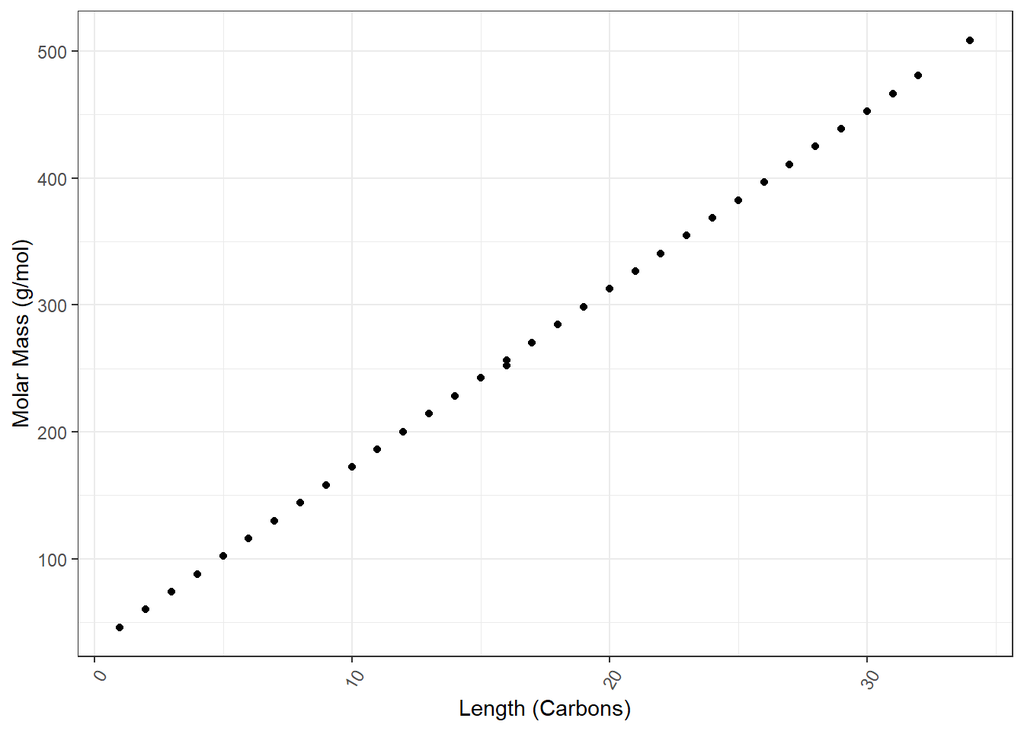

```r
sat.length <- sub(':0.*', "", Fatty.Acids$Delta.notation)
sat.length <- strtoi(sat.length)


Sat.Acids<- Fatty.Acids %>%
  mutate(Delta.notation = sat.length) %>%
  drop_na(Delta.notation)


ggplot(data=Sat.Acids, aes(x=Delta.notation, y=Mass)) + geom_point() +
  theme_bw() +
  scale_fill_paletteer_d("miscpalettes::brightPastel") +
  theme(axis.text.x = element_text(angle=60, hjust=1)) +
  ylab('Molar Mass (g/mol)')  +
  xlab('Length (Carbons)')
```

### Linearity

As expected, the amount of carbons per lipids increases linearly with molar mass. Lipidomics often acquires data via Mass Spec and NMR, so this trend acts as a powerful tool for lipid identification.

```r
Top.Cited <-Fatty.Acids %>%
  arrange(desc(Result.Count))

howlong <-dim(Top.Cited)
howlong <- howlong[1]/25
Top.Cited <- Top.Cited[1:howlong,]
glimpse(Top.Cited)
```

```
## Rows: 19
## Columns: 6
## $ Name           <chr> "Hexadecanoic acid", "Octadecanoic acid", "9-Octadeceno…
## $ Common.Name    <chr> "Palmitic acid", "Stearic acid", "Oleic acid", "Linolei…
## $ Delta.notation <chr> " 16:0", " 18:0", " 18:1-delta-9c", " 18:2-delta-9c,12c…
## $ Formula        <chr> "C16 H32 O2", "C18 H36 O2", "C18 H34 O2", "C18 H32 O2",…
## $ Mass           <dbl> 256.42, 284.48, 282.46, 280.45, 278.43, 312.53, 228.37,…
## $ Result.Count   <int> 13061, 12479, 9078, 8839, 6459, 5931, 5909, 4320, 4134,…
```

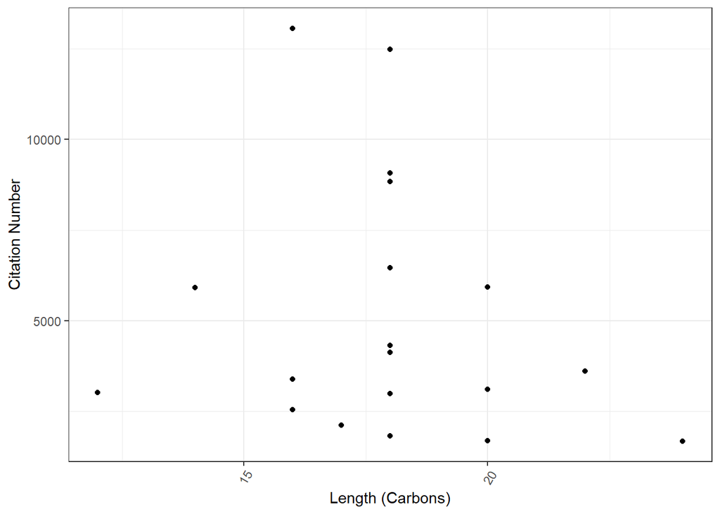

```r
top.length <- sub(':.*', "", Top.Cited$Delta.notation)
top.length <- strtoi(top.length)
top.sat <- sub('*.:', "", Top.Cited$Delta.notation)
top.sat <- substring(top.sat,3,3)
top.sat <- strtoi(top.sat)
Top.Cited$top.sat <- top.sat
Top.Cited$top.length <- top.length


ggplot(data=Top.Cited, aes(x=top.length, y=Result.Count)) + geom_point() +
  theme_bw() +
  scale_fill_paletteer_d("miscpalettes::brightPastel") +
  theme(axis.text.x = element_text(angle=60, hjust=1)) +
  ylab('Citation Number')  +
  xlab('Length (Carbons)')
```

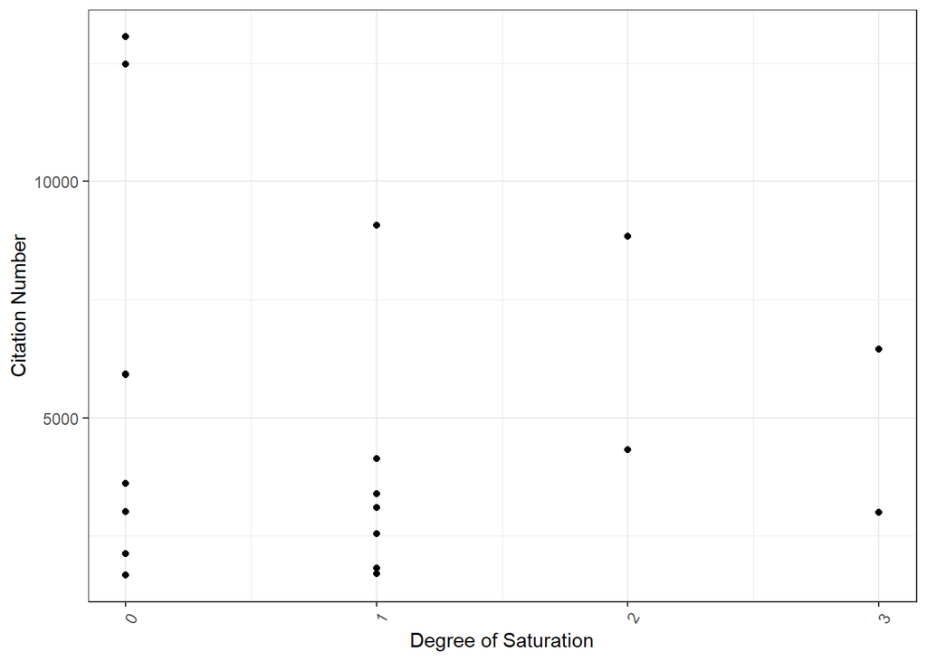

```r
ggplot(data=Top.Cited, aes(x=top.sat, y=Result.Count)) + geom_point() +
  theme_bw() +
  scale_fill_paletteer_d("miscpalettes::brightPastel") +
  theme(axis.text.x = element_text(angle=60, hjust=1)) +
  ylab('Citation Number')  +
  xlab('Degree of Saturation')
```

Lipid length doesn’t seem to directly correlate to citation number, but the majority of highly cited lipids are from the middle of the range. This is likely due to researchers choosing the most “average” lipid, or perhaps the median length lipids have more widespread biological relevance.

### Conclusion

In conclusion, we were able to determine the overall number of saturated lipids, correlate saturated lipid length to mass, isolate the most cited lipids, and determine trends between citation number, saturation degree, and length.